# Project 2: Data Mining, Classification, Prediction

## Linear Classifier

```r
# Logistic Regression
logistic_fit <- glm(arrest ~ age, data = Rossi, family = "binomial")
prob_reg <- predict(logistic_fit, type = "response")
class_diag(prob_reg, truth = Rossi$arrest, positive = 1)
```

```
##            acc sens spec ppv  f1  ba    auc
## Metrics 0.7361    0    1 NaN NaN 0.5 0.6403
```

```r
# .6403

logistic_fit2 <- glm(arrest ~ prio, data = Rossi, family = "binomial")
prob_reg2 <- predict(logistic_fit2, type = "response")
class_diag(prob_reg2, truth = Rossi$arrest, positive = 1)
```

```
##            acc   sens   spec    ppv     f1     ba    auc
## Metrics 0.7384 0.0351 0.9906 0.5714 0.0661 0.5128 0.5964
```

```r
# .5964

logistic_fit3 <- glm(arrest ~ educ, data = Rossi, family = "binomial")
prob_reg3 <- predict(logistic_fit3, type = "response")
class_diag(prob_reg3, truth = Rossi$arrest, positive = 1)
```

```
##            acc sens spec ppv  f1  ba    auc
## Metrics 0.7361    0    1 NaN NaN 0.5 0.5658
```

```r
# .5658

logistic_fit4 <- glm(arrest ~ employment, data = Rossi, family = "binomial")
prob_reg4 <- predict(logistic_fit4, type = "response")
class_diag(prob_reg4, truth = Rossi$arrest, positive = 1)
```

```
##            acc   sens   spec    ppv     f1     ba    auc
## Metrics 0.7454 0.3333 0.8931 0.5278 0.4086 0.6132 0.7619
```

```r
# .7619

logistic_fit5 <- glm(arrest ~ age + employment + prio + educ,
    data = Rossi, family = "binomial")
prob_reg5 <- predict(logistic_fit5, type = "response")
class_diag(prob_reg5, truth = Rossi$arrest, positive = 1)
```

```
##            acc   sens   spec    ppv     f1     ba    auc
## Metrics 0.7616 0.3684 0.9025 0.5753 0.4492 0.6355 0.7794
```

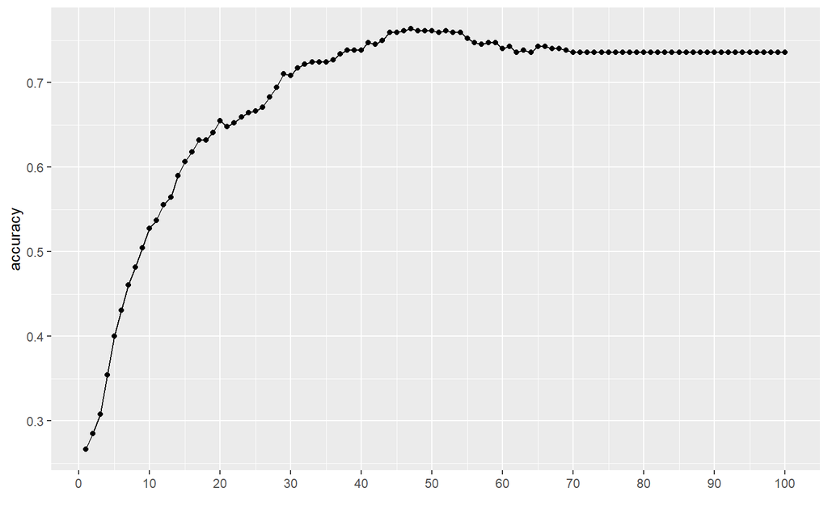

```r
# .7794

# Confusion Matrix
y <- Rossi$arrest
y <- factor(y, levels = c(1, 0))
x <- prob_reg5 * 100
accuracy <- vector()
cutoff <- 1:100
for (i in cutoff) {
    y_hat <- ifelse(x > i, 1, 0)
    accuracy[i] <- mean(y == y_hat)
}
qplot(y = accuracy) + geom_line() + scale_x_continuous(n.breaks = 10)
```

```r
max(accuracy)
```

```
## [1] 0.7638889
```

```r
cutoff[which.max(accuracy)]
```

```
## [1] 47
```

```r
y_hat <- ifelse(x > 47, 1, 0)
y_hat <- factor(y_hat, levels = c(1, 0))
table(actual = y, predicted = y_hat) %>%
    addmargins
```

```
##       predicted
## actual   1   0 Sum
##    1    51  63 114
##    0    39 279 318
##    Sum  90 342 432
```

```r
# k-fold CV
k = 10
data <- Rossi[sample(nrow(Rossi)), ]
folds <- cut(seq(1:nrow(Rossi)), breaks = k, labels = F)
diags <- NULL
for (i in 1:k) {
    train <- Rossi[folds != i, ]
    test <- Rossi[folds == i, ]
    truth <- test$arrest
    fit <- glm(arrest ~ age + employment + prio + educ, data = train,
        family = "binomial")
    probs <- predict(fit, newdata = test, type = "response")
    diags <- rbind(diags, class_diag(probs, truth, positive = 1))
}
summarize_all(diags, mean)
```

```
##       acc    sens    spec     ppv      f1      ba     auc
## 1 0.75011 0.32855 0.90057 0.52865 0.39289 0.61457 0.76415
```

After running a logistic regression on each numeric variables against the binary variable of arrest, the variables with the highest area under the curve was age and total weeks of employment which means they are the best factors in predicting whether someone gets arrested again. I ran another logistic regression with all the numeric variables and the area under the curve was .7794 which means the model is fairly good. The confusion matrix shows that 330 participants out of 432 were accurately identified as arrested or not. After performing a k-fold cross-validation with 10 folds, the area under the curve is .76415 which is similar to the logistic regression model in performing fairly. There does not seem to be signs of overfitting since the cross-validation did not perform significantly worse than the logistic regression model.